# Differences in Speeches during War-time and Peace-time

Xinhu Wang (UNI: xw2439)

10/1/2017

I want to analyze the sentiment of the speeches and see if there are noticable difference between wartime speeches and peacetime(non-wartime) speeches.

### Downloaded necessary packages

```r
packages.used=c("rvest", "tibble", "qdap",
                "sentimentr", "gplots", "dplyr",
                "tm", "syuzhet", "factoextra",
                "beeswarm", "scales", "RColorBrewer",
                "RANN", "tm", "topicmodels", "wordcloud")

# check packages that need to be installed.
packages.needed=setdiff(packages.used,
                        intersect(installed.packages()[,1],
                                  packages.used))
# install additional packages
if(length(packages.needed)>0){
  install.packages(packages.needed, dependencies = TRUE)
}

# load packages
library("rvest")
library("tibble")
library("sentimentr")
library("gplots")
library("dplyr")
library("tm")
library("syuzhet")
library("factoextra")
library("beeswarm")
library("scales")
library("RColorBrewer")
library("RANN")
library("tm")
library("topicmodels")
library("wordcloud")
library("tidytext")

library("xlsx")
library(rJava)
library("qdap")

source("../lib/plotstacked.R")
source("../lib/speechFuncs.R")
```

This notebook was prepared with the following environmental settings.

```r
print(R.version)
```

```
##                _
## platform       x86_64-apple-darwin15.6.0
## arch           x86_64
## os             darwin15.6.0
## system         x86_64, darwin15.6.0
## status
## major          3
## minor          4.1
## year           2017
## month          06
## day            30
## svn rev        72865
## language       R
## version.string R version 3.4.1 (2017-06-30)
## nickname       Single Candle
```

In order to analyze the sentiment of wartime speeches and non-wartime speeches, I chose ten significant inauguration speeches for each group.

```r
folder.path="../data/inauguralSpeeches/"
speeches=list.files(path = folder.path, pattern = "*.txt")
prex.out=substr(speeches, 6, nchar(speeches)-4)
ff.all<-Corpus(DirSource(folder.path))

#Speech selected
speech.war=c("AbrahamLincoln-1","AbrahamLincoln-2","WoodrowWilson-1","WoodrowWilson-2","FranklinDRoosevelt-2","FranklinDRoosevelt-3","FranklinDRoosevelt-4","JohnFKennedy-1","RonaldReagan-1","GeorgeWBush-2")

speech.nonwar=c("HerbertHoover-1","GeorgeBush-1","RichardNixon-1","WilliamJClinton-2","RonaldReagan-2","JimmyCarter-1","GeorgeWBush-1", "BarackObama-1", "BarackObama-2", "DonaldJTrump-1")
```

### Generate Term-Document Matrices

```r
# Term-Document Matrix (TDM) function
generateTDM <- function(corpus){
  corpus<-tm_map(corpus, stripWhitespace)
  corpus<-tm_map(corpus, content_transformer(tolower))
  corpus<-tm_map(corpus, removeWords, stopwords("english"))
  corpus<-tm_map(corpus, removeWords, character(0))
  corpus<-tm_map(corpus, removePunctuation)

  #TF-IDF weighted Term-Document Matrix

  TDM <- TermDocumentMatrix(corpus,
                          control = list(weighting = function(x)
                                             weightTfIdf(x, normalize =FALSE),
                                         stopwords = TRUE))
  TDM.tidy=tidy(TDM)
  TDM.overall=summarise(group_by(TDM.tidy, term), sum(count))

  return(TDM.overall)
}

# Document-Term Matrix (DTM) function
generateDTM <- function(corpus){
  corpus<-tm_map(corpus, stripWhitespace)
  corpus<-tm_map(corpus, content_transformer(tolower))
  corpus<-tm_map(corpus, removeWords, stopwords("english"))
  corpus<-tm_map(corpus, removeWords, character(0))
  corpus<-tm_map(corpus, removePunctuation)

  #Document-Term Matrix

  DTM <- DocumentTermMatrix(corpus,
                          control = list(weighting = function(x)
                                             weightTfIdf(x, normalize =FALSE),
                                         stopwords = TRUE))
  DTM.tidy <- tidy(DTM)
  DTM.overall <- summarise(group_by(DTM.tidy, term), sum(count))
  r <- list(tidy = DTM.tidy, overall = DTM.overall)

  return(r)
}

#generate TDM & DTM for all speeches, war and non-war period
tdm.war <- generateTDM(c(ff.all[[1]],ff.all[[2]],ff.all[[56]],ff.all[[57]],ff.all[[13]],ff.all[[14]],ff.all[[15]],ff.all[[35]],ff.all[[41]],ff.all[[21]]))
tdm.nonwar <- generateTDM(c(ff.all[[5]],ff.all[[6]],ff.all[[9]],ff.all[[17]],ff.all[[20]],ff.all[[25]],ff.all[[33]],ff.all[[39]],ff.all[[42]],ff.all[[53]]))
tdm.all <- generateTDM(ff.all)

dtm.war <- generateDTM(c(ff.all[[1]],ff.all[[2]],ff.all[[56]],ff.all[[57]],ff.all[[13]],ff.all[[14]],ff.all[[15]],ff.all[[35]],ff.all[[41]],ff.all[[21]]))[[1]]
dtm.nonwar <- generateDTM(c(ff.all[[5]],ff.all[[6]],ff.all[[9]],ff.all[[17]],ff.all[[20]],ff.all[[25]],ff.all[[33]],ff.all[[39]],ff.all[[42]],ff.all[[53]]))[[1]]
dtm.all <- generateDTM(ff.all)
```

### Generate word clouds

Let’s see what are the most common words appeared during war time, and compare them with those during other times.

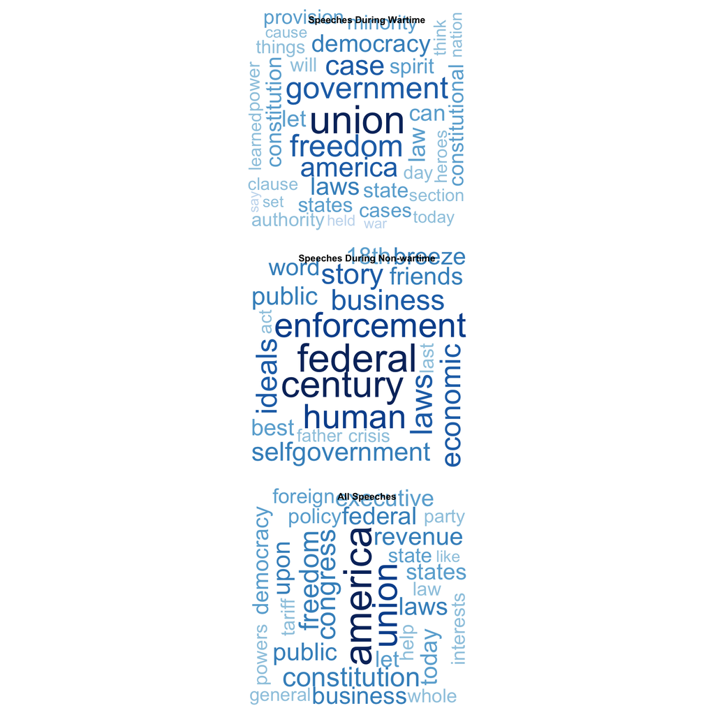

```r
generateWordCloud <- function(tdm, mytitle){
  wordcloud(tdm$term, tdm$`sum(count)`,
          scale=c(5,0.5),
          max.words=100,
          min.freq=1,
          random.order=FALSE,
          rot.per=0.3,
          use.r.layout=T,
          random.color=FALSE,
          colors=brewer.pal(9,"Blues"))
  title(main = mytitle)
}

par(mfcol = c(3,1))
generateWordCloud(tdm.war, 'Speeches During Wartime')
generateWordCloud(tdm.nonwar, 'Speeches During Non-wartime')
generateWordCloud(tdm.all, 'All Speeches')
```

From the word cloud graphs, we can see during war time, most inauguration speeches were focusing on “union”, “freedom”, and “government”. While during the rest of time, “federal”, “business”, and “enforcement” were the most common words mentioned by presidents. This makes sense because during the war time, people would concern more about freedom, laws, and what the government could do to overcome the war. In contrast, during the peace time, presidents would talk more about economy, business, and human, which are the topics that the society concerned about.

Overall, the most commonly mentioned words through all speeches were “America”, “union”, “congress”, “freedom”, “business”, etc.

### Sentiment Analysis

After looking at the word cloud, I want to know the tone of speeches and see whether there is a significant difference in sentiment/emotion between groups.

First we need to extract the speeches and split them into sentences. Then, I calculated the emotional scores for eight different emotions. Lastly, in order to visualize the result, I used bar plot to show the distribution of each emotion by their scores.

```r
#Split speech into sentences

#For wartime speeches
L1=sent_detect(ff.all[[1]]$content,endmarks = c("?", ".", "!", "|",";"))#LINCOLN-1

L2=sent_detect(ff.all[[2]]$content,endmarks = c("?", ".", "!", "|",";"))#LINCOLN-2

W1=sent_detect(ff.all[[56]]$content,endmarks = c("?", ".", "!", "|",";"))#WoodrowWilson-1

W2=sent_detect(ff.all[[57]]$content,endmarks = c("?", ".", "!", "|",";"))#WoodrowWilson-2

F2=sent_detect(ff.all[[13]]$content,endmarks = c("?", ".", "!", "|",";"))#FranklinDRoosevelt-2

F3=sent_detect(ff.all[[14]]$content,endmarks = c("?", ".", "!", "|",";"))#FranklinDRoosevelt-3

F4=sent_detect(ff.all[[15]]$content,endmarks = c("?", ".", "!", "|",";"))#FranklinDRoosevelt-4

J1=sent_detect(ff.all[[35]]$content,endmarks = c("?", ".", "!", "|",";"))#JohnFKenndy-1

R1=sent_detect(ff.all[[41]]$content,endmarks = c("?", ".", "!", "|",";"))#RonaldReagan-1

G2=sent_detect(ff.all[[21]]$content,endmarks= c("?", ".", "!", "|",";"))#GeorgeWBush-2

#For non-wartime speeches
H1=sent_detect(ff.all[[25]]$content,endmarks = c("?", ".", "!", "|",";")) #"HerbertHoover-1"

C2=sent_detect(ff.all[[53]]$content,endmarks = c("?", ".", "!", "|",";"))#WilliamJClinton-2

R2=sent_detect(ff.all[[42]]$content,endmarks = c("?", ".", "!", "|",";"))#RonaldReagan-2

JC1=sent_detect(ff.all[[33]]$content,endmarks = c("?", ".", "!", "|",";"))#JimmyCarter-1

G1=sent_detect(ff.all[[20]]$content,endmarks= c("?", ".", "!", "|",";"))#GeorgeWBush-1

B1=sent_detect(ff.all[[5]]$content,endmarks = c("?", ".", "!", "|",";"))#"BarackObama-1"

B2=sent_detect(ff.all[[6]]$content,endmarks = c("?", ".", "!", "|",";"))#"BarackObama-2"

D1=sent_detect(ff.all[[9]]$content,endmarks = c("?", ".", "!", "|",";"))#"DonaldJTrump-1"

GB1=sent_detect(ff.all[[17]]$content,endmarks = c("?", ".", "!", "|",";"))#"GeorgeBush-1"

N1=sent_detect(ff.all[[39]]$content,endmarks = c("?", ".", "!", "|",";"))#"RichardNixon-1"

#Create emotion matrix of these presidents with sentences
sentence.list = list(L1,L2,W1,W2,F2,F3,F4,J1,R1,G2,H1,C2,R2,JC1,G1,B1,B2,D1,GB1,N1)

title.list = c(rep("AbrahamLincoln-1",length(L1)),rep("AbrahamLincoln-2",length(L2)),rep("WoodrowWilson-1",length(W1)),rep("WoodrowWilson-2",length(W2)),rep("FranklinDRoosevelt-2",length(F2)),rep("FranklinDRoosevelt-3",length(F3)),rep("FranklinDRoosevelt-4",length(F4)),rep("JohnFKennedy-1",length(J1)),rep("RonaldReagan-1",length(R1)),rep("GeorgeWBush-2",length(G2)),rep("HerbertHoover-1",length(H1)),rep("WilliamJClinton-2",length(C2)),rep("RonaldReagan-2",length(R2)),rep("JimmyCarter-1",length(JC1)),rep("GeorgeWBush-1",length(G1)),rep("BarackObama-1",length(B1)),rep("BarackObama-2",length(B2)),rep("DonaldJTrump-1",length(D1)),rep("GeorgeBush-1",length(GB1)),rep("RichardNixon-1",length(N1)))

emotion.matrix = cbind(title.list,c(L1,L2,W1,W2,F2,F3,F4,J1,R1,G2,H1,C2,R2,JC1,G1,B1,B2,D1,GB1,N1))

colnames(emotion.matrix)=c("President","Sentences")


# Generate emotion matrix
interm.matrix = NULL

for(i in 1 : length(sentence.list)){
  emotions=diag(1/(word_count(sentence.list[[i]])+0.01))%*%as.matrix(get_nrc_sentiment(sentence.list[[i]]))

  colnames(emotions)=c( "anger", "anticipation", "disgust", "fear", "joy", "sadness", "surprise", "trust", "negative", "positive")

  interm.matrix = rbind(interm.matrix,cbind(sent.id=as.numeric(1:length(sentence.list[[i]])),nword=word_count(sentence.list[[i]]),as.matrix(emotions)))
}

emotion.matrix = as.data.frame(cbind(emotion.matrix,interm.matrix))

#Convert factors into numeric variables
Factor_to_Numeric=function(df){
  for(i in 3:14){
    df[,i] = as.numeric(as.character(df[,i]))
  }
  return(df)
}


emotion.matrix = Factor_to_Numeric(emotion.matrix)

#Summarize Data for Cluster analysis

#For war group
presid.summary.war=tbl_df(emotion.matrix)%>%
  filter(President %in% c(speech.war))%>%
  group_by(President)%>%
  summarise(
    anger=mean(anger,na.rm=TRUE),
    anticipation=mean(anticipation,na.rm=TRUE),
    disgust=mean(disgust,na.rm=TRUE),
    fear=mean(fear,na.rm=TRUE),
    joy=mean(joy,na.rm=TRUE),
    sadness=mean(sadness,na.rm=TRUE),
    surprise=mean(surprise,na.rm=TRUE),
    trust=mean(trust,na.rm=TRUE)
    )

presid.summary.war=as.data.frame(presid.summary.war)

rownames(presid.summary.war)=as.character((presid.summary.war[,1]))


#For non-war speeches
presid.summary.nonwar=tbl_df(emotion.matrix)%>%
  filter(President%in%c(speech.nonwar))%>%
  group_by(President)%>%
  summarise(
    anger=mean(anger,na.rm=TRUE),
    anticipation=mean(anticipation,na.rm=TRUE),
    disgust=mean(disgust,na.rm=TRUE),
    fear=mean(fear,na.rm=TRUE),
    joy=mean(joy,na.rm=TRUE),
    sadness=mean(sadness,na.rm=TRUE),
    surprise=mean(surprise,na.rm=TRUE),
    trust=mean(trust,na.rm=TRUE)
    )

presid.summary.nonwar=as.data.frame(presid.summary.nonwar)
rownames(presid.summary.nonwar)=as.character((presid.summary.nonwar[,1]))


#For both groups
presid.summary.all=tbl_df(emotion.matrix)%>%

  filter(President%in%c(speech.war,speech.nonwar))%>%
  group_by(President)%>%
  summarise(
    anger=mean(anger,na.rm=TRUE),
    anticipation=mean(anticipation,na.rm=TRUE),
    disgust=mean(disgust,na.rm=TRUE),
    fear=mean(fear,na.rm=TRUE),
    joy=mean(joy,na.rm=TRUE),
    sadness=mean(sadness,na.rm=TRUE),
    surprise=mean(surprise,na.rm=TRUE),
    trust=mean(trust,na.rm=TRUE)
    )

presid.summary.all=as.data.frame(presid.summary.all)
rownames(presid.summary.all)=as.character((presid.summary.all[,1]))
```

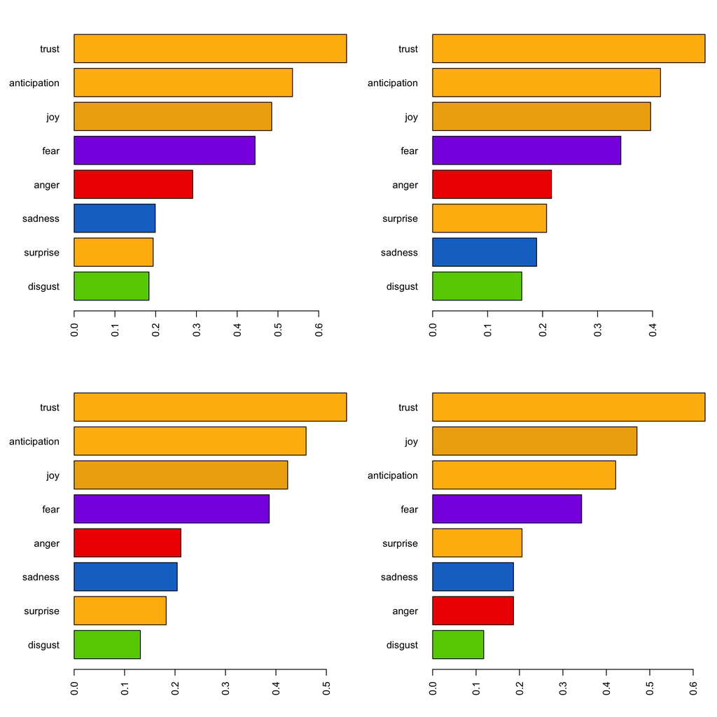

```r
#Plot Emotion Barplot
Emotion_Barplot= function(pop){
  par(mar=c(4, 6, 2, 1))

  emo.means=colMeans(select(subset(emotion.matrix,emotion.matrix$President==pop), anger:trust)>0.01,na.rm=TRUE)

  col.use=c("red2", "darkgoldenrod1",
            "chartreuse3", "blueviolet",
            "darkgoldenrod2", "dodgerblue3",
            "darkgoldenrod1", "darkgoldenrod1")

  barplot(emo.means[order(emo.means)], las=2, col=col.use[order(emo.means)], horiz=T)
}
par(mfrow=c(2,2))
Emotion_Barplot(speech.nonwar[1])
Emotion_Barplot(speech.nonwar[4])
Emotion_Barplot(speech.nonwar[5])
Emotion_Barplot(speech.nonwar[7])
```

I chose four speeches during non-wartime, and it looks like Trust, Anticipation, and joy are the dominant tone during those speeches. What about the tone for war time speeches?

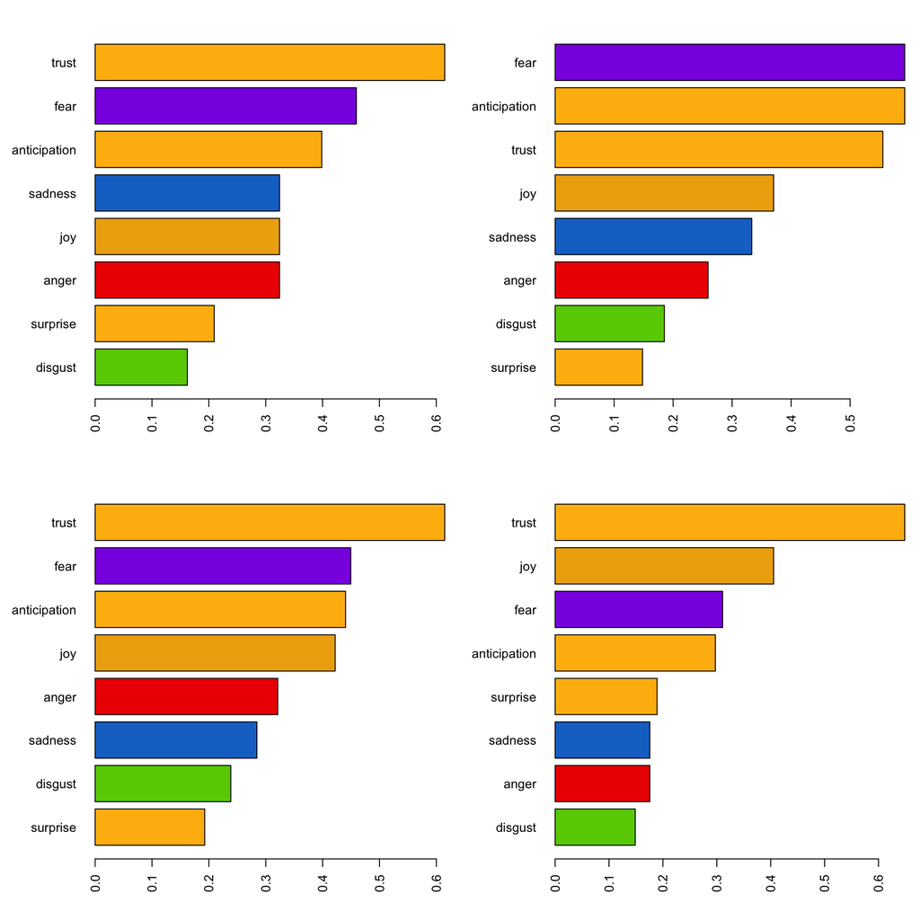

```r
par(mfrow=c(2,2))
Emotion_Barplot(speech.war[1])
Emotion_Barplot(speech.war[2])
Emotion_Barplot(speech.war[5])
Emotion_Barplot(speech.war[6])
```

From the selected four speeches, we can easily see that fear and sadness were expressed more in war-time speeches. Other than that, trust is also a major sentiment in presidents’ talk.

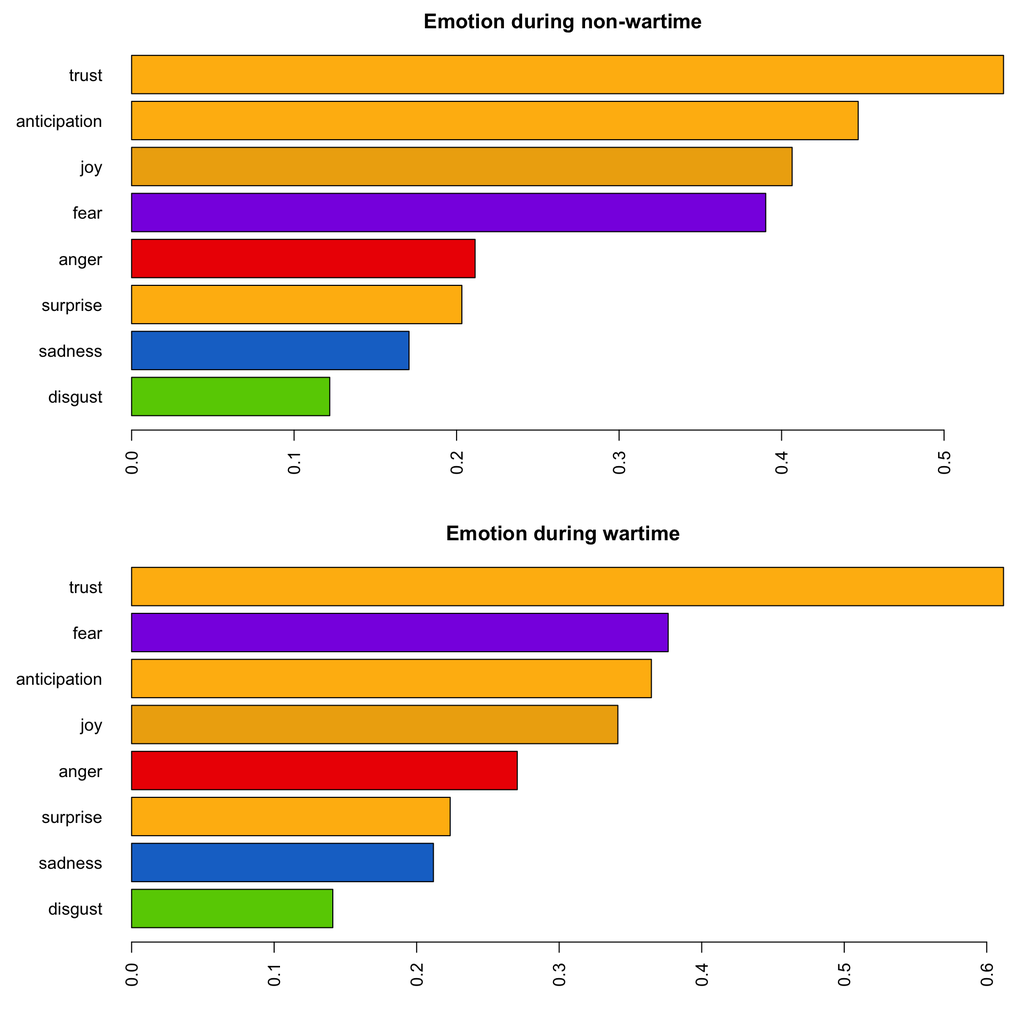

```r
# Compare emotions between war time and peace time
par(mfrow=c(2,1))
Emotion_Barplot(speech.nonwar)
title(main = "Emotion during non-wartime")

Emotion_Barplot(speech.war)
title(main = "Emotion during wartime")
```

### Cluster plots

Use emotion scores of both groups and apply k-means cluster algorithm.

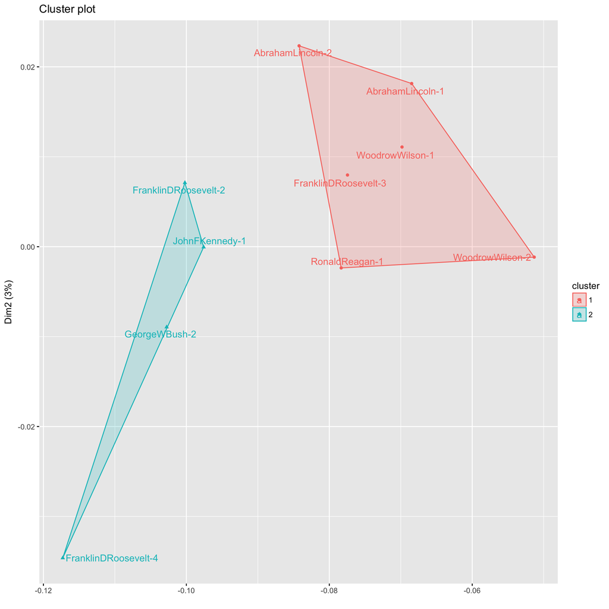

```r
par(mfrow = c(2, 2))
km.res=kmeans(presid.summary.war[,-1],2,iter.max=200,nstart=5)
fviz_cluster(km.res,
             stand=F, repel= TRUE,
             data = presid.summary.war[,-1], xlab="", xaxt="n",
             show.clust.cent=FALSE)
```

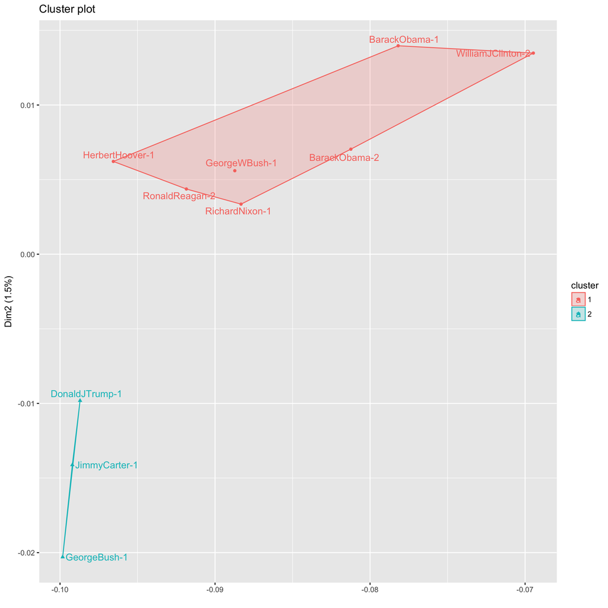

```r
km.res=kmeans(presid.summary.nonwar[,-1],2,iter.max=200,nstart=5)
fviz_cluster(km.res,
             stand=F, repel= TRUE,
             data = presid.summary.nonwar[,-1], xlab="", xaxt="n",
             show.clust.cent=FALSE)
```

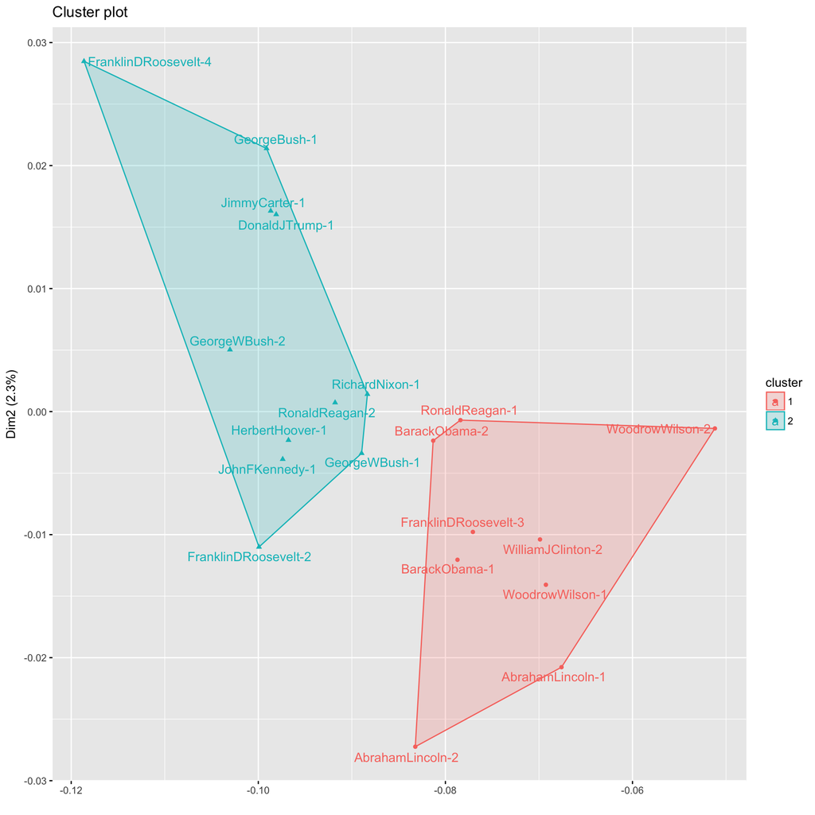

```r
km.res=kmeans(presid.summary.all[,-1],2,iter.max=200,nstart=5)
fviz_cluster(km.res,
             stand=F, repel= TRUE,
             data = presid.summary.all[,-1], xlab="", xaxt="n",
             show.clust.cent=FALSE)
```

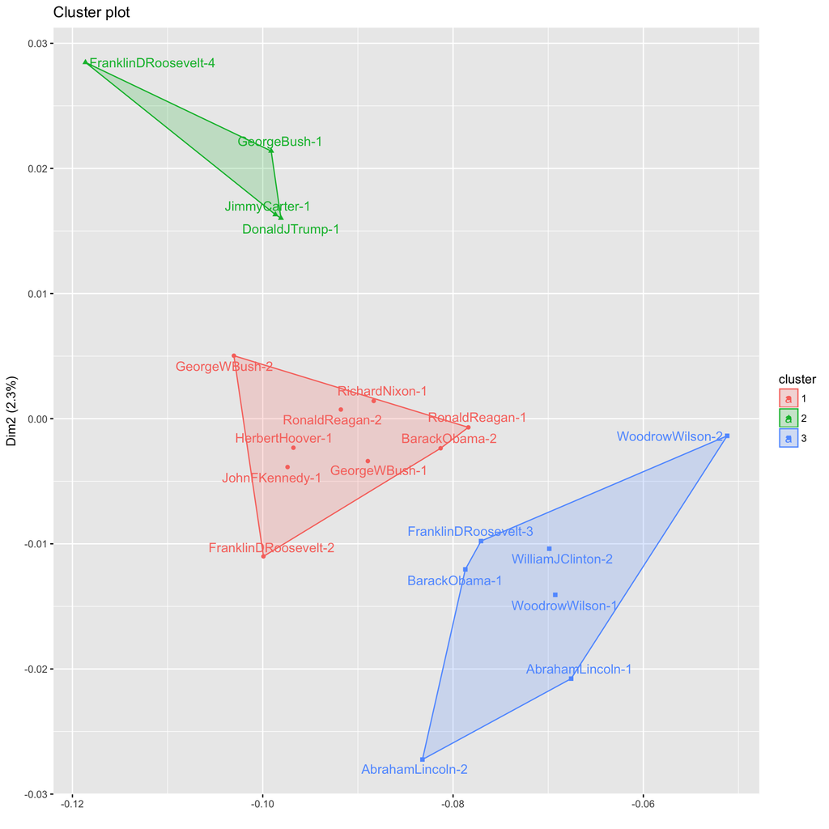

```r
km.res=kmeans(presid.summary.all[,-1],3,iter.max=200,nstart=5)
fviz_cluster(km.res,
             stand=F, repel= TRUE,
             data = presid.summary.all[,-1], xlab="", xaxt="n",
             show.clust.cent=FALSE)
```

I classified all speeches into two and three clusters respectively. From the analysis using three clusters, we are not able to find significant difference among those speeches from two groups, but from the two-clusters plot, we can see that most of the speeches are clustered according to the war/nonwar groups.

### Conclusion

Above are several text mining and classification analysis I did on speeches from wartime group and non-wartime group. The patterns and results are interesting, some of them are also surprising. I’m sure there are many other informations that we can work on in order to find more patterns.